# Problem Statement:

We'll optimize a simple mathematical function called the Rosenbrock function, which is often used as a benchmark for optimization algorithms. The Rosenbrock function is defined as:

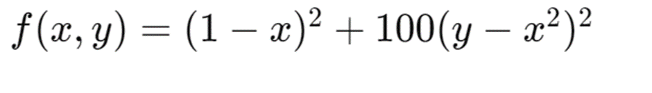

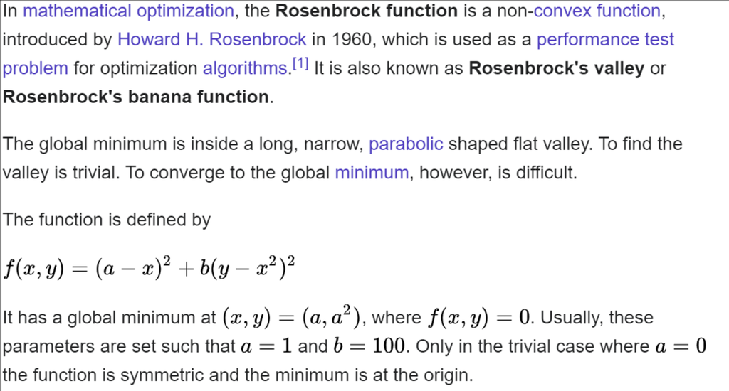

# Ant Colony Optimization (ACO):

```python
import numpy as np

# Define the Rosenbrock function
def rosenbrock(x, y):
    return (1 - x)**2 + 100 * (y - x**2)**2

# Ant Colony Optimization
def ant_colony_optimization(num_ants, num_iterations, evaporation_rate=0.5, pheromone_constant=1.0, heuristic_constant=1.0):
    # Initialize pheromone matrix
    pheromone_matrix = np.ones((num_ants, 2)) / num_ants

    # Initialize best solution
    best_solution = None
    best_fitness = float('inf')

    # Main loop
    for _ in range(num_iterations):
        # Generate solutions (ants)
        ants = np.random.uniform(-5, 5, size=(num_ants, 2))

        # Evaluate fitness
        fitness = np.array([rosenbrock(x, y) for x, y in ants])

        # Update pheromone levels
        for i in range(num_ants):
            pheromone_matrix[i] *= (1 - evaporation_rate)
            pheromone_matrix[i] += pheromone_constant / fitness[i]

        # Select best solution
        best_ant_index = np.argmin(fitness)
        if fitness[best_ant_index] < best_fitness:
            best_solution = ants[best_ant_index]
            best_fitness = fitness[best_ant_index]

    return best_solution, best_fitness

# Parameters
num_ants = 20
num_iterations = 100

# Run Ant Colony Optimization
best_solution_aco, best_fitness_aco = ant_colony_optimization(num_ants, num_iterations)

# Output results
print("Best Solution (Ant Colony Optimization):", best_solution_aco)
print("Best Fitness (Ant Colony Optimization):", best_fitness_aco)
```

```
Best Solution (Ant Colony Optimization): [0.78034426 0.63181318]
Best Fitness (Ant Colony Optimization): 0.10057987638949041
```

# Implementation Steps for Ant Colony Optimization (ACO):

Initialize Pheromone Levels: Initialize the pheromone levels on the edges of the search space.

Generate Ants: Generate an initial population of ants with random positions in the search space.

Evaluate Fitness: Evaluate the fitness (objective function value) of each ant by calculating the Rosenbrock function for its position.

Update Pheromone Levels: Update the pheromone levels on the edges based on the quality of the solutions found by ants.

Repeat until convergence or for a fixed number of iterations:

Local Pheromone Update: At each step, ants deposit pheromone on the edges they traverse, with the amount based on the quality of the solution found. Global Pheromone Update: After all ants complete their tours, global pheromone update is performed to evaporate existing pheromone and reinforce good paths.

Output Best Solution: Output the best solution found by the algorithm, which corresponds to the ant with the best fitness value.

# ACO here is mimicking how real ants find food sources. Let's break down the code to understand how it works:

1. Setting the Stage:

Rosenbrock Function: This defines the "landscape" the ants are exploring. It's a mathematical function with highs and lows, and the goal is to find the lowest point (minimum).

Pheromone Matrix: Imagine this as a grid representing all possible paths the ants can take. Initially, all paths have the same "attractiveness" (pheromone level).

2. The Ants' Search:

Main Loop: The loop runs for a set number of iterations, simulating the ants searching over time.

Generate Ants: At each iteration, the code creates a random set of positions for the "ants" within a defined area.

Evaluate Fitness: Each ant's position is evaluated using the Rosenbrock function. This tells us how "good" (low fitness) or "bad" (high fitness) that particular location is.

3. Learning from Experience:

Evaporation: The pheromone on all paths weakens over time, mimicking how real pheromone trails fade. This helps prevent getting stuck in local minima.

4. Finding the Best Path:

Track Best Solution: The code keeps track of the best ant (the one that found the lowest point so far) and its corresponding fitness score.

# Bee Colony Optimization:

```python
import numpy as np

# Define the Rosenbrock function
def rosenbrock(x, y):
    return (1 - x)**2 + 100 * (y - x**2)**2

# Bee Colony Optimization
def bee_colony_optimization(num_bees, num_iterations):
    # Initialize bees
    bees = np.random.uniform(-5, 5, size=(num_bees, 2))

    # Initialize best solution
    best_solution = None
    best_fitness = float('inf')

    # Main loop
    for _ in range(num_iterations):
        # Evaluate fitness
        fitness = np.array([rosenbrock(x, y) for x, y in bees])

        # Communication and recruitment
        best_bee_index = np.argmin(fitness)
        best_bee = bees[best_bee_index]
        other_bees = bees[np.arange(len(bees)) != best_bee_index]
        for i in range(len(bees)):
            if np.random.rand() < 0.5:
                bees[i] = best_bee + np.random.uniform(-1, 1, size=2)
            else:
                bees[i] = other_bees[np.random.randint(len(other_bees))] + np.random.uniform(-1, 1, size=2)

        # Select best solution
        best_bee_index = np.argmin(fitness)
        if fitness[best_bee_index] < best_fitness:
            best_solution = bees[best_bee_index]
            best_fitness = fitness[best_bee_index]

    return best_solution, best_fitness

# Parameters
num_bees = 20
num_iterations = 100

# Run Bee Colony Optimization
best_solution_bco, best_fitness_bco = bee_colony_optimization(num_bees, num_iterations)

# Output results
print("Best Solution (Bee Colony Optimization):", best_solution_bco)
print("Best Fitness (Bee Colony Optimization):", best_fitness_bco)
```

```
Best Solution (Bee Colony Optimization): [ 2.06075172 -0.19708776]
Best Fitness (Bee Colony Optimization): 0.0011464846061509763
```

# Implementation Steps for Bee Colony Optimization (BCO):

Generate Bees: Generate an initial population of bees with random positions in the search space.

Evaluate Fitness: Evaluate the fitness (objective function value) of each bee by calculating the Rosenbrock function for its position.

Repeat until convergence or for a fixed number of iterations:

Bee Communication and Recruitment: Bees communicate information about good solutions and recruit other bees to promising locations.

Update Solutions: Bees update their positions based on the results of the local search.

Output Best Solution: Output the best solution found by the algorithm, which corresponds to the bee with the best fitness value.

# BCO here simulates how honey bees forage for nectar. Let's break down the algorithm:

Bee Initialization:

A set of "bees" is created with random positions within the search space (defined by the problem). These positions represent potential solutions. Fitness Evaluation:

Each bee's position is evaluated using the Rosenbrock function. This gives a "fitness score" indicating how good (low fitness) or bad (high fitness) that location is for finding the minimum. Communication and Recruitment:

Employed bees: Their positions are modified by adding a random value within a certain range to the best bee's position. This allows them to search near the promising area found by the best bee. Onlooker bees: They choose another bee's location (excluding the best bee) and modify it by adding a random value. This encourages exploration around areas with good potential based on other bees' findings. Selection and Update:

The loop repeats for a set number of iterations, allowing the bees to explore and refine their search based on communication and individual exploration. Mathematical Parts: The code itself doesn't involve complex math beyond the Rosenbrock function used for fitness evaluation. However, the core concept of BCO relies on probabilistic selection during the onlooker bee stage.

Overall, BCO works through a combination of individual exploration, communication of discoveries, and probabilistic selection, mimicking the collaborative foraging behavior of honey bees to find optimal solutions.

# Particle Swarm Optimization (PSO):

```python
import numpy as np

# Define the Rosenbrock function
def rosenbrock(x, y):
    return (1 - x)**2 + 100 * (y - x**2)**2

# Particle Swarm Optimization (PSO) algorithm
def pso(num_particles, num_iterations, inertia_weight=0.9, cognitive_weight=2.0, social_weight=2.0):
    # Initialize swarm
    particles = np.random.uniform(-5, 5, size=(num_particles, 2))
    velocities = np.zeros_like(particles)
    best_positions = particles.copy()
    best_fitness_values = np.array([rosenbrock(x, y) for x, y in particles])
    global_best_index = np.argmin(best_fitness_values)
    global_best_position = particles[global_best_index].copy()
    global_best_fitness = best_fitness_values[global_best_index]

    # PSO main loop
    for _ in range(num_iterations):
        # Update velocities and positions
        cognitive_component = cognitive_weight * np.random.rand() * (best_positions - particles)
        social_component = social_weight * np.random.rand() * (global_best_position - particles)
        velocities = inertia_weight * velocities + cognitive_component + social_component
        particles += velocities

        # Clip positions to bounds
        particles = np.clip(particles, -5, 5)

        # Update fitness values
        fitness_values = np.array([rosenbrock(x, y) for x, y in particles])

        # Update best positions and global best
        improved_indices = np.where(fitness_values < best_fitness_values)
        best_positions[improved_indices] = particles[improved_indices]
        best_fitness_values[improved_indices] = fitness_values[improved_indices]
        global_best_index = np.argmin(best_fitness_values)
        global_best_position = particles[global_best_index].copy()
        global_best_fitness = best_fitness_values[global_best_index]

    return global_best_position, global_best_fitness

# Parameters
num_particles = 50
num_iterations = 100

# Run PSO algorithm
best_solution, best_fitness = pso(num_particles, num_iterations)

# Output results
print("PSO Best Solution:", best_solution)
print("PSO Best Fitness:", best_fitness)
```

```
PSO Best Solution: [ 1.69333463 -0.59827795]
PSO Best Fitness: 0.008570934833437521
```

# Particle Swarm Optimization (PSO) Implementation Steps:

Evaluate Fitness: Evaluate the fitness (objective function value) of each particle by calculating the Rosenbrock function.

Update Particle Velocities and Positions: Update particle velocities and positions using the PSO equations based on individual and global best positions.

Repeat: Repeat steps 2-3 for a certain number of iterations or until a convergence criterion is met.

Output: Output the best solution found.

# PSO simulates the collective movement of birds or fish searching for food. Here's how it works:

Particle Initialization:

A swarm of "particles" is created with random positions within the search space (defined by the problem). These positions represent potential solutions. Each particle also has a velocity, which determines its direction and movement in the search space. Fitness Evaluation:

The fitness of each particle's position is evaluated using the Rosenbrock function. This gives a "fitness score" indicating how good (low fitness) that location is for finding the minimum. Velocity Update:

The velocity of each particle is updated based on three factors: Inertia: This term encourages particles to continue in their current direction with some momentum, mimicking the tendency of birds or fish to keep moving in a certain direction for a while. It's controlled by the inertia_weight parameter. Cognitive Component: This term encourages particles to explore areas closer to their own best positions found so far. It's based on the difference between the particle's current position and its best position, scaled by the cognitive_weight and a random factor. Social Component: This term encourages particles to explore areas closer to the swarm's best position found so far. It's based on the difference between the particle's current position and the global best position, scaled by the social_weight and a random factor. Position Update:

Each particle's position is updated by adding its current velocity to its previous position. Boundary Handling:

If a particle's updated position goes outside the defined search space, it's typically clipped to the boundaries to keep it within the valid range. Fitness Update:

The fitness score is recalculated for each particle's new position. Best Position Update:

Each particle compares its new fitness score to its previous best score. If the new score is better (lower for minimization problems), the particle's best position and fitness are updated. Global Best Update:

All particles' fitness scores are compared, and the particle with the overall best fitness (lowest score) is identified. The swarm's global best position and fitness are updated if a new best solution is found. Iteration:

Steps 3 to 8 are repeated for a set number of iterations, allowing the particles to explore the search space and converge towards the optimal solution.